# R Notebook

# Introduction to phylogenies in R

This tutorial gives a basic introduction to phylogenies in the R language and statistical computing environment.

## R phylogenetics packages

R phylogenetics is built on the contributed packages for phylogenetics in R, and there are many such packages. Let’s begin today by installing a few critical packages, such as ape, phangorn, phytools, and geiger. To get the most recent CRAN version of these packages, you will need to have R 3.3.x installed on your computer!

```r
R.version
```

```
##                _
## platform       x86_64-apple-darwin15.6.0
## arch           x86_64
## os             darwin15.6.0
## system         x86_64, darwin15.6.0
## status
## major          3
## minor          6.3
## year           2020
## month          02
## day            29
## svn rev        77875
## language       R
## version.string R version 3.6.3 (2020-02-29)
## nickname       Holding the Windsock
```

> MOI: I installed other packages that the original R exercice didn’t installed but that I needed to install. When I did install different packages, I got a message telling me to restart Rstudio. Whenever I said yes, I had to load the packages again. Thus, I said NO, and it worked. I recomend that you do the same.

> MOI: While you install R packages, they might fail. You can read the warning messages and some times you will see that it tells you why it failed. Usually, it is because it was not able to fain a particular package. In order to overcome this problem, you can add another package to be installed in the below R code chunk before the package that had problems and that should be fine.

```r
#install.packages("ape")
#install.packages("phangorn")
#install.packages("phytools")
#install.packages("geiger")
#install.packages("devtools") #package added by Moi
#install.packages("maps")     #package added by Moi
```

We can verify that we have the same versions of these packages installed by using the base function `packageVersion`:

```r
packageVersion("ape")
```

```
## [1] '5.4.1'
```

```r
packageVersion("phangorn")
```

```
## [1] '2.5.5'
```

```r
packageVersion("phytools")
```

```
## [1] '0.7.70'
```

```r
packageVersion("geiger")
```

```
## [1] '2.0.7'
```

I strongly recommend that you use the package versions shown above (or more recent versions) rather than older editions.

Installing automatically from CRAN using `install.packages` installs not only your target package - but also any libraries on which that package depends, if that package has not yet been installed.

It is also possible to install more recent development versions of some R packages from GitHub using the package devtools. For instance, we can install the most recent development version of phytools from GitHub as follows:

```r
library(devtools)
install_github("liamrevell/phytools")
```

```
## Skipping install of 'phytools' from a github remote, the SHA1 (7b375aa7) has not changed since last install.
##   Use `force = TRUE` to force installation
```

## The `"phylo"` object in R

Now we’ve installed critical packages (ape, phangorn, phytools, geiger). The most important core package for phylogenies in R is called “ape”, which stands for **A**nalysis of **P**hylogenetics and **E**volution in R.

```r
## load ape
library(ape)
```

“ape” does many different things. To get started let’s read a ‘toy’ example vertebrate tree from a Newick text string:

```r
## read tree from string
text.string<-
    "(((((((cow, pig),whale),(bat,(lemur,human))),(robin,iguana)),coelacanth),gold_fish),shark);"
vert.tree<-read.tree(text=text.string)
```

We can visualize this phylogeny in R in a number of different ways. Let’s plot this phylogeny in three different styles:

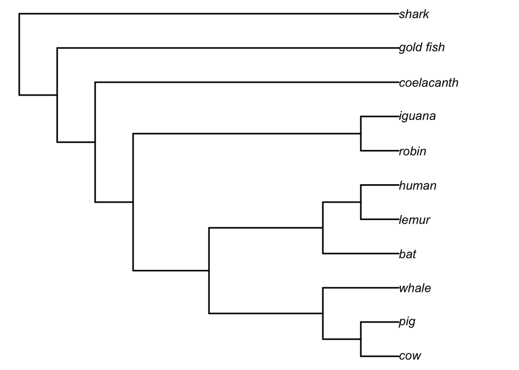

```r
plot(vert.tree,no.margin=TRUE,edge.width=2)
```

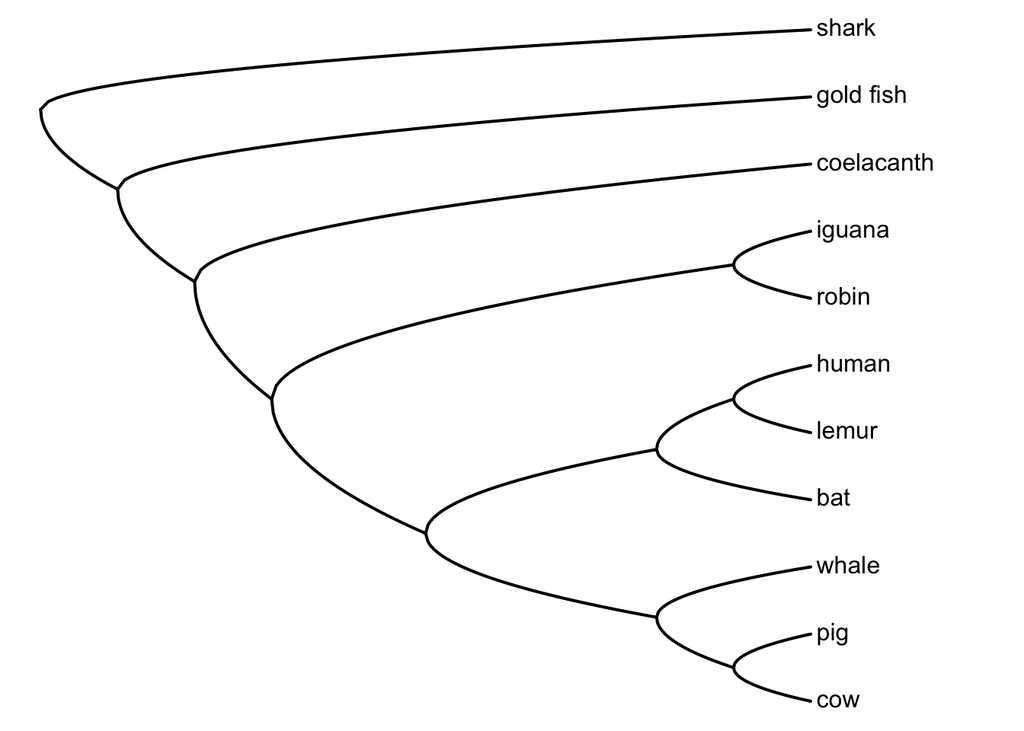

```r
## load phytools
library(phytools)
roundPhylogram(vert.tree)
```

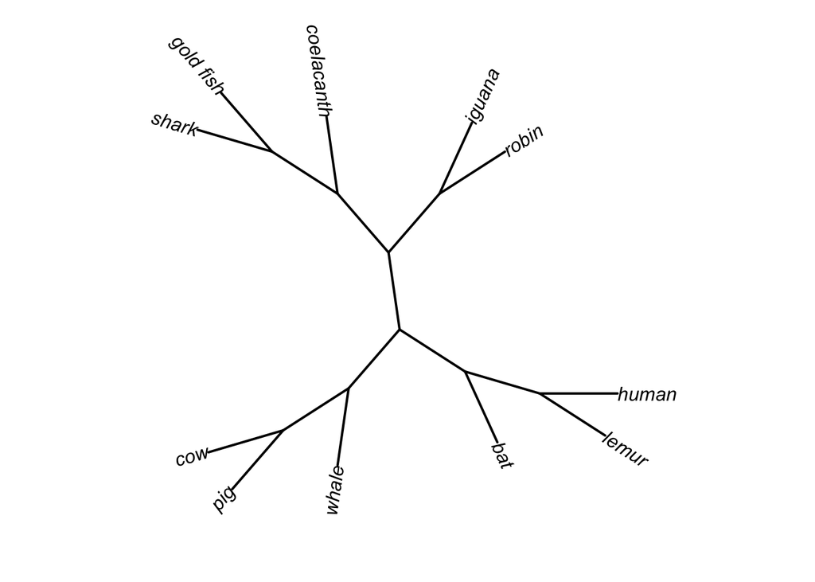

```r
plot(unroot(vert.tree),type="unrooted",no.margin=TRUE,lab4ut="axial",
    edge.width=2)
```

The object created in memory when we simulate or estimate a phylogeny, or read one from an input file, is a list of class `"phylo"`.

Remember, a list is just a customizable object type that can combine different objects of different types. For instance, a list might have a vector of real numbers (with mode `"numeric"`) as its first element; and then a vector of strings (with mode `"character"`) as its second element; and so on. Assigning our tree with a special class, `"phylo"`, is just a convenient way to tell special functions in R how to treat that object.

An object of class `"phylo"` has at least three parts. These are normally hidden, for instance, just typing the name of your `"phylo"` object does not give you the structure in memory, as it does for many R objects:

```r
vert.tree
```

```
##
## Phylogenetic tree with 11 tips and 10 internal nodes.
##
## Tip labels:
##   cow, pig, whale, bat, lemur, human, ...
##
## Rooted; no branch lengths.
```

Instead, something called an S3 `print` method is activate to print to screen a summary of some of the important attributes of that object.

We can, however, reveal the internal structure of our object as follows:

```r
str(vert.tree)
```

```
## List of 3
##  $ edge     : int [1:20, 1:2] 12 13 14 15 16 17 18 18 17 16 ...
##  $ Nnode    : int 10
##  $ tip.label: chr [1:11] "cow" "pig" "whale" "bat" ...
##  - attr(*, "class")= chr "phylo"
##  - attr(*, "order")= chr "cladewise"
```

To understand the structure of a `"phylo"` object a little bit more clearly, let’s read in a much simpler phylogeny, and then decompose it to its essential components:

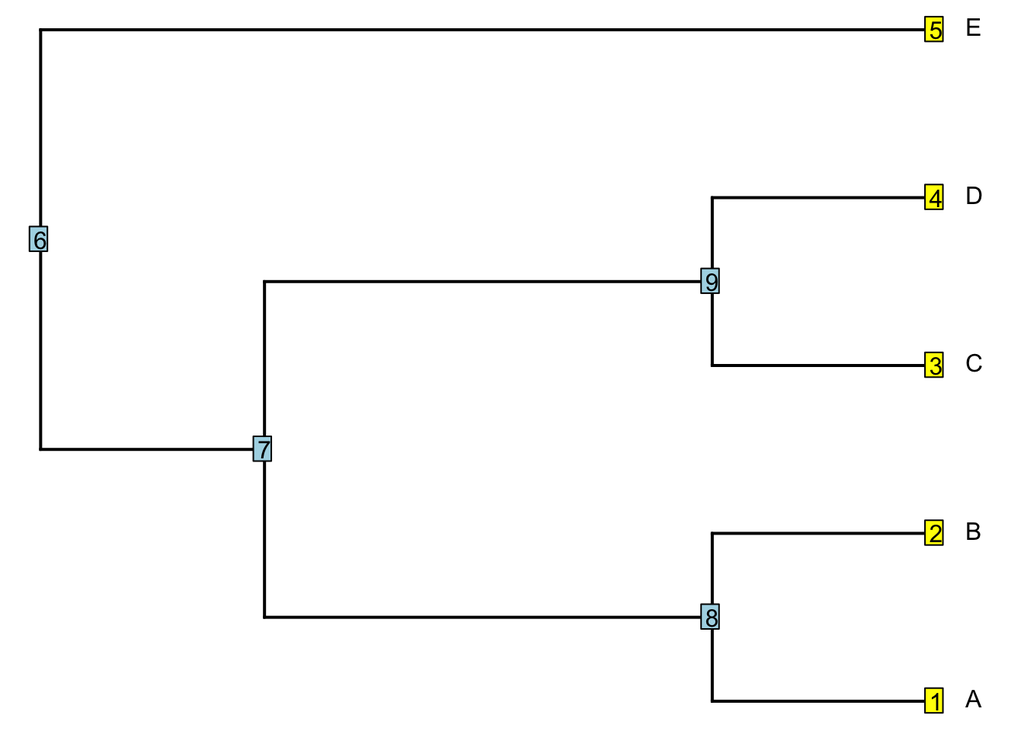

```r
tree<-read.tree(text="(((A,B),(C,D)),E);")
plotTree(tree,offset=1)
tiplabels()
nodelabels()
```

Here I have overlain the ‘node numbers’ - the indices from the `"phylo"` object `edge` which is a matrix containing the starting & ending node indices for each edge:

```r
tree$edge
```

```
##      [,1] [,2]
## [1,]    6    7
## [2,]    7    8
## [3,]    8    1
## [4,]    8    2
## [5,]    7    9
## [6,]    9    3
## [7,]    9    4
## [8,]    6    5
```

We can see:

1. that `tree$edge` has a number of rows equal to the number of edges (8) in this tree; and
2. that each edge starts and ends with a unique pair of indices. Furthermore, by convention the indices 1 through N for N tips correspond with the tip nodes (species) in the tree.

The other components of importance are the vector `tip.label` and an integer `Nnode` which gives the number of interior nodes in the tree:

```r
tree$tip.label
```

```
## [1] "A" "B" "C" "D" "E"
```

```r
tree$Nnode
```

```
## [1] 4
```

An object of class `"phylo"` also (by definition) has at least one attribute - its class. This is just a value to tell various methods in R what to do with an object of this type. For instance, if we call the method `plot`, R knows to use the method `plot.phylo` in the R package `“ape”`.

An object of class `"phylo"` can also have other components, the most common of which is `edge.length` (a vector of class `"numeric"` containing all the edge lengths). In addition, other elements & attributes can be added for special types of phylogenetic trees.

## Writing & reading phylogenetic trees

We can easily write & read trees to & from files, for example if we download the file anole.tre:

```r
anolis.tree<-read.tree(file="anole.tre")
anolis.tree
```

```
##
## Phylogenetic tree with 82 tips and 81 internal nodes.
##
## Tip labels:
##   Anolis_ahli, Anolis_allogus, Anolis_rubribarbus, Anolis_imias, Anolis_sagrei, Anolis_bremeri, ...
##
## Rooted; includes branch lengths.
```

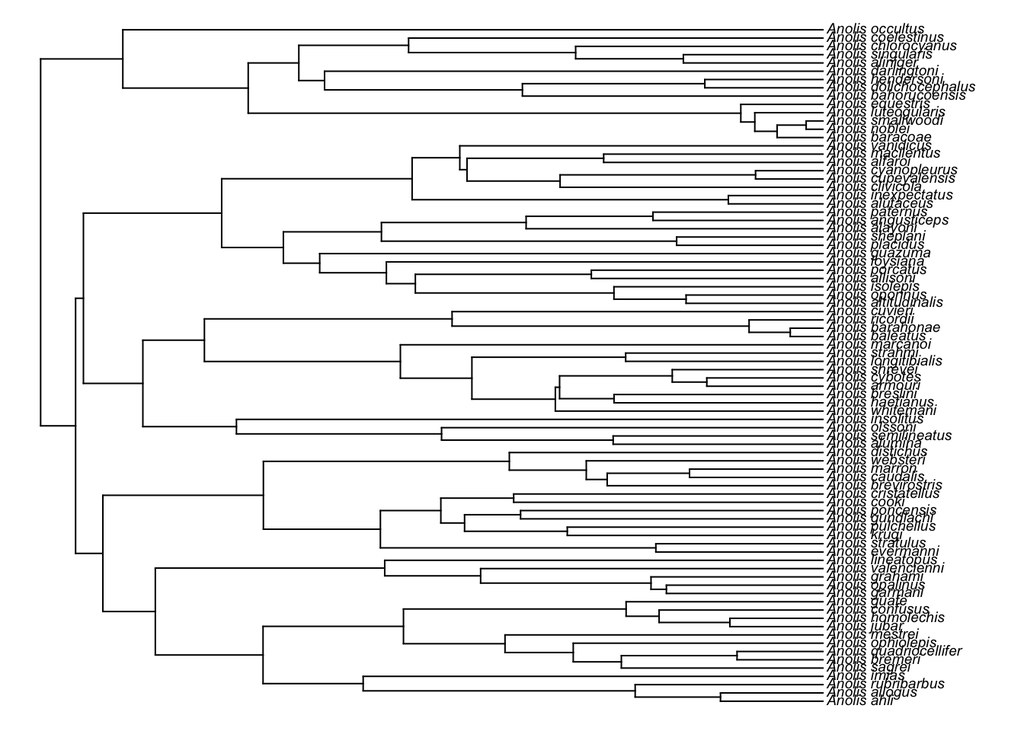

```r
plotTree(anolis.tree,ftype="i",fsize=0.6,lwd=1)
```

This is a tree containing:

```r
Ntip(anolis.tree)
```

```
## [1] 82
```

82 species of lizards in the neotropical lizard genus Anolis.

We can also write trees to file. For instance, we can easily write our five taxon tree from before to a simple text file in Newick style:

> MOI: Next command will create a text file name example.tre in your folder with the tree in netweek format. You can check it yourself, but the command “cat(…” just reads the file you indicate.

```r
write.tree(tree,file="example.tre")
## this is what our file looks like (you can open it to check)
cat(readLines("example.tre"),sep="\n")
```

```
## (((A,B),(C,D)),E);
```

## Plotting, & manipulating trees

There are a range of ways in which we can plot trees in R.

For instance, we can easily create an *unrooted cladogram* of the *Anolis* phylogeny we read in earlier. Let’s do that:

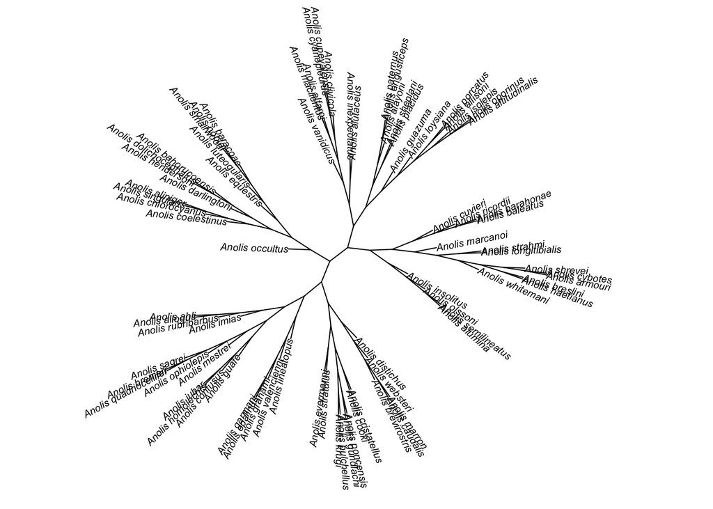

```r
plot(unroot(anolis.tree),type="unrooted",cex=0.6,
    use.edge.length=FALSE,lab4ut="axial",
    no.margin=TRUE)
```

Another convenient plotting method for large *rooted* trees is a circular or ‘fan’ tree:

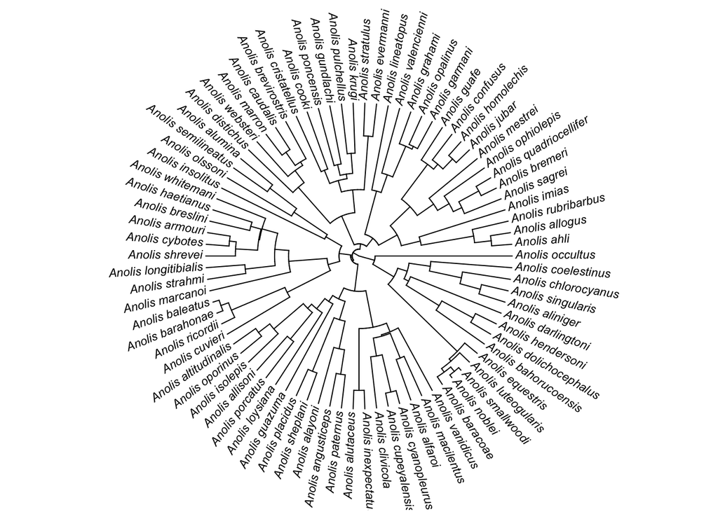

```r
plotTree(anolis.tree,type="fan",fsize=0.7,lwd=1,
    ftype="i")
```

```r
pr.species<-c("cooki","poncensis","gundlachi","pulchellus","stratulus",
    "krugi","evermanni","occultus","cuvieri","cristatellus")
ii<-sapply(pr.species,grep,anolis.tree$tip.label)
ii
```

```
##        cooki    poncensis    gundlachi   pulchellus    stratulus        krugi
##           25           24           23           22           20           21
##    evermanni     occultus      cuvieri cristatellus
##           19           82           48           26
```

```r
pr.species<-anolis.tree$tip.label[ii]
pr.species
```

```
##  [1] "Anolis_cooki"        "Anolis_poncensis"    "Anolis_gundlachi"
##  [4] "Anolis_pulchellus"   "Anolis_stratulus"    "Anolis_krugi"
##  [7] "Anolis_evermanni"    "Anolis_occultus"     "Anolis_cuvieri"
## [10] "Anolis_cristatellus"
```

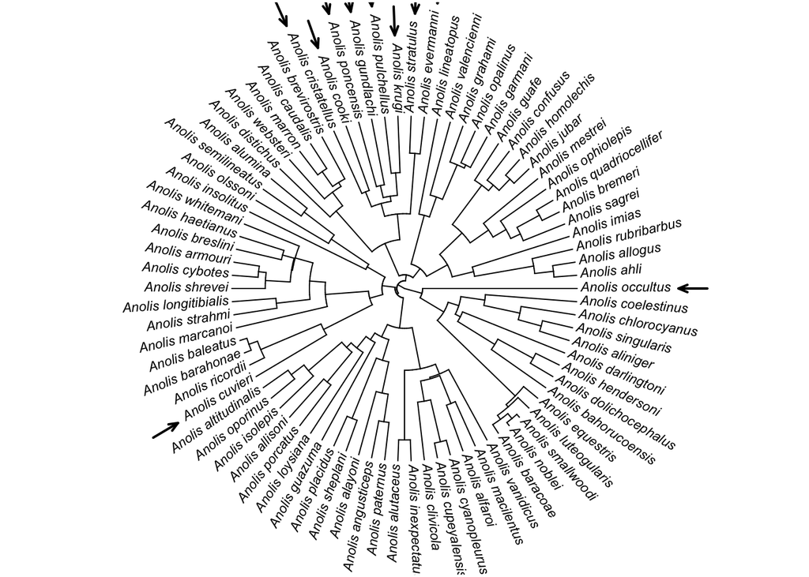

```r
plotTree(anolis.tree,type="fan",fsize=0.7,lwd=1,
    ftype="i")
add.arrow(anolis.tree,tip=ii,arrl=1)
```

Now let’s prune these species from the tree:

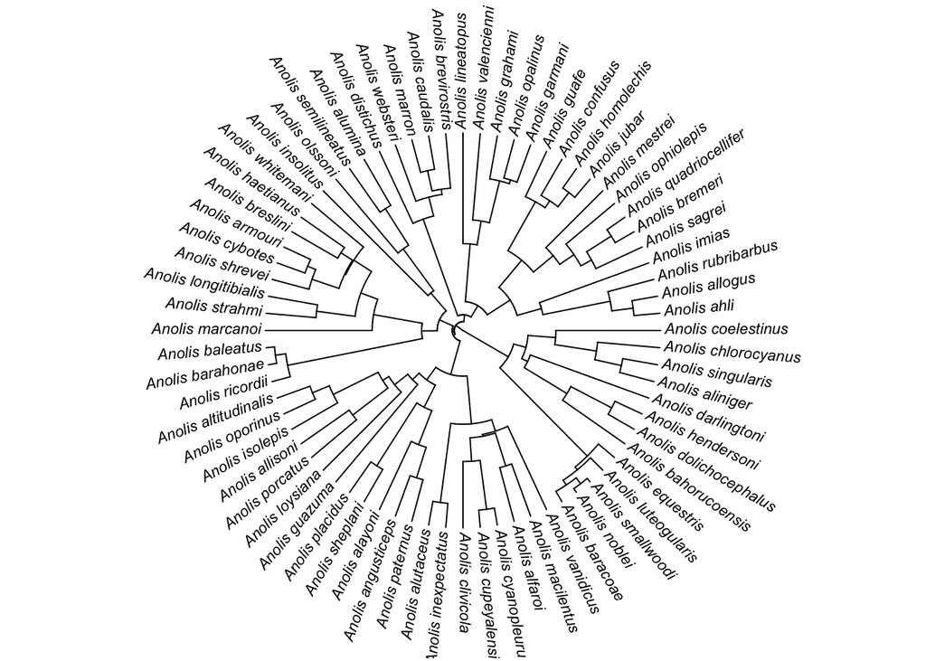

```r
anolis.noPR<-drop.tip(anolis.tree,pr.species)
plotTree(anolis.noPR,type="fan",fsize=0.7,lwd=1,
    ftype="i")
```

Or, we can extract the clade that includes all but two of the species:

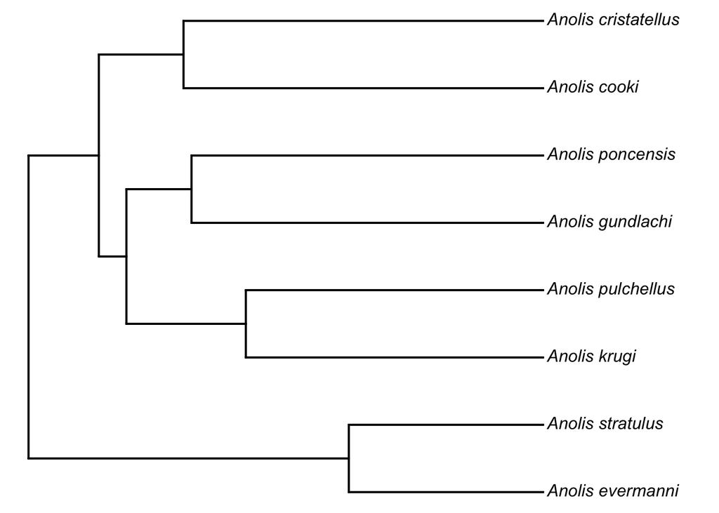

```r
node<-fastMRCA(anolis.tree,"Anolis_evermanni",
    "Anolis_cristatellus")
pr.clade<-extract.clade(anolis.tree,node)
plotTree(pr.clade,ftype="i")
```

Now, let’s prune everything in the tree except these species:

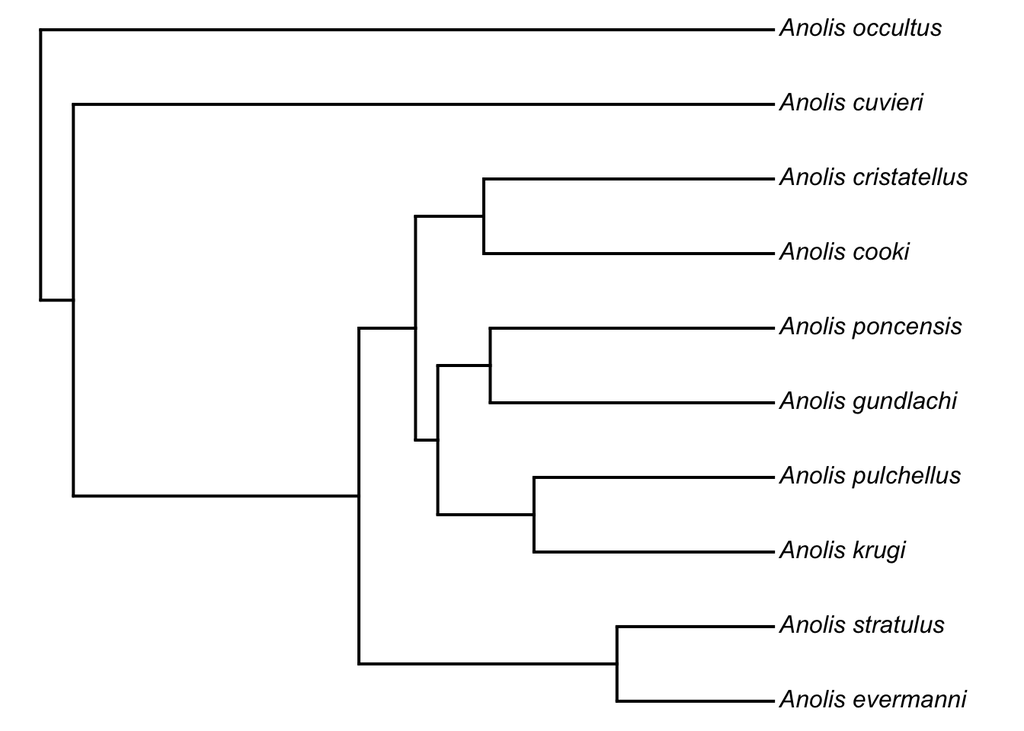

```r
pr.tree<-drop.tip(anolis.tree,
    setdiff(anolis.tree$tip.label,pr.species))
plotTree(pr.tree,ftype="i")
```

Finally, we can do it *interactively* using `collapseTree`

> MOI: For this to work, you need to run the two following commands directly on the console. To quite the interactive mode, I had to press ESC.

```r
#anolis.pruned<-collapseTree(anolis.tree)
#plotTree(anolis.pruned,type="fan",fsize=0.7,lwd=1, ftype="i")
```

## Binary & polytomous trees

“ape” and most other phylogenetics packages are equipped to handle phylogenies that are binary or multifurcating; however not all functions will be. We can easily check if our tree is binary, and convert between binary & multifurcating trees.

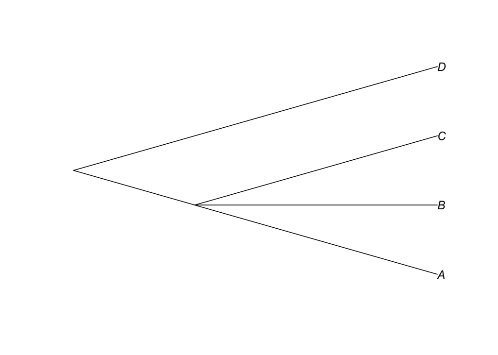

```r
t1<-read.tree(text="((A,B,C),D);")
plot(t1,type="cladogram")
```

```r
## check if binary
is.binary.tree(t1)
```

```
## [1] FALSE
```

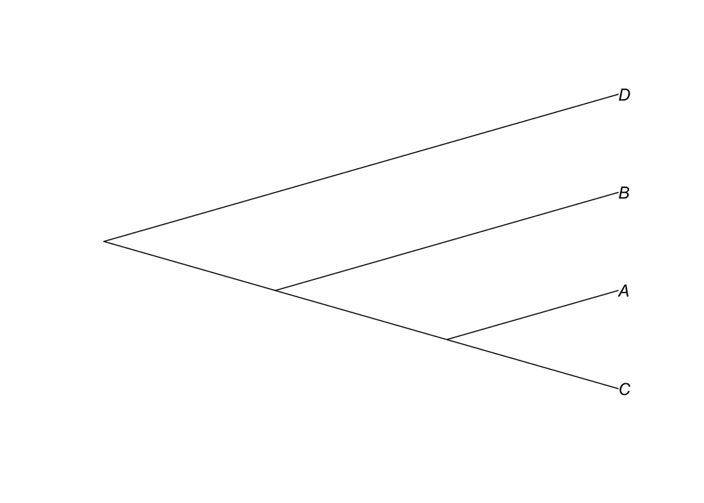

```r
## randomly resolve polytomies
t2<-multi2di(t1)
plot(t2,type="cladogram")
```

```r
is.binary.tree(t2)
```

```
## [1] TRUE
```

## Miscellaneous (rotating nodes, re-rooting, etc…)

Lots of other manipulations are possible in R, but here are some simple ones:

> MOI: the `seed` is to fix a random process. For example, if you randomly draw a number between 1 to 10, every time you run it, you will get a different number. However, if you set the `seed` you will allways get the same result. To see that, you can comment the `set.seed(1)`, run the chunk multiple times (to see that you get different trees), and then uncoment the `set.seed(1)` and run again multipe times (to see taht you allways get the same result).

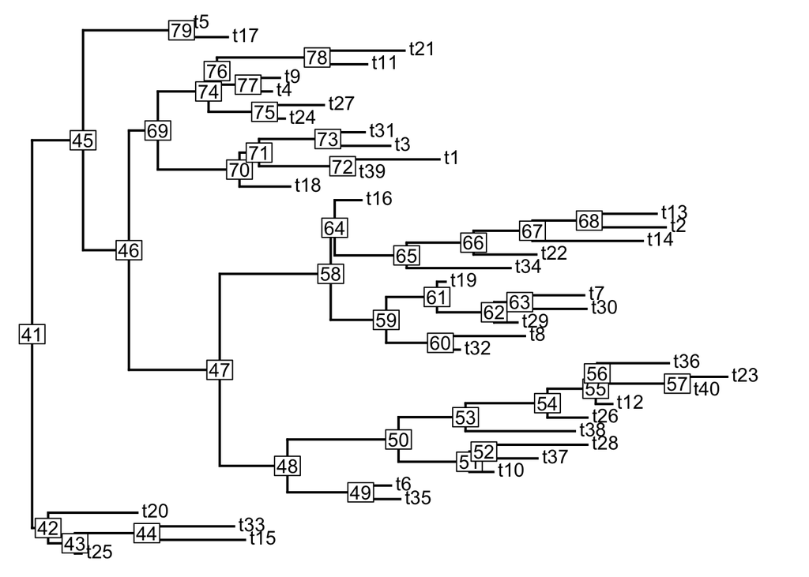

```r
set.seed(1) ## so we all have the same thing!
## rotating nodes
tree<-rtree(n=40)
plotTree(tree,node.numbers=T)
```

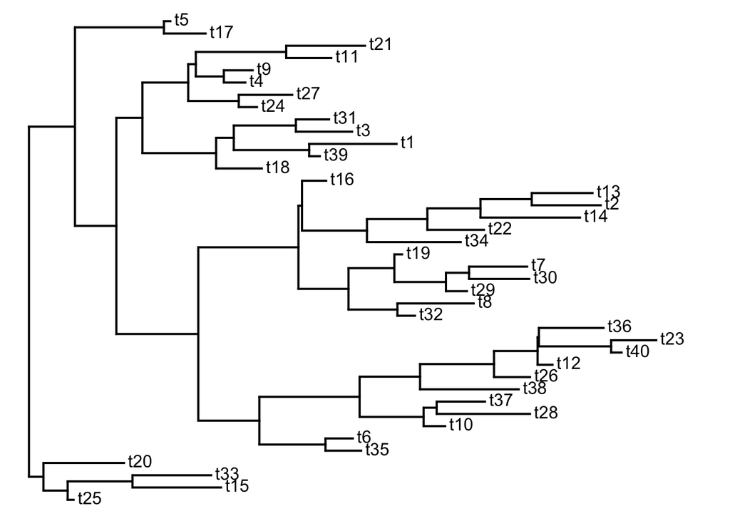

```r
## first, rotate about node #52
rt.52<-rotate(tree,52)
plotTree(rt.52)
```

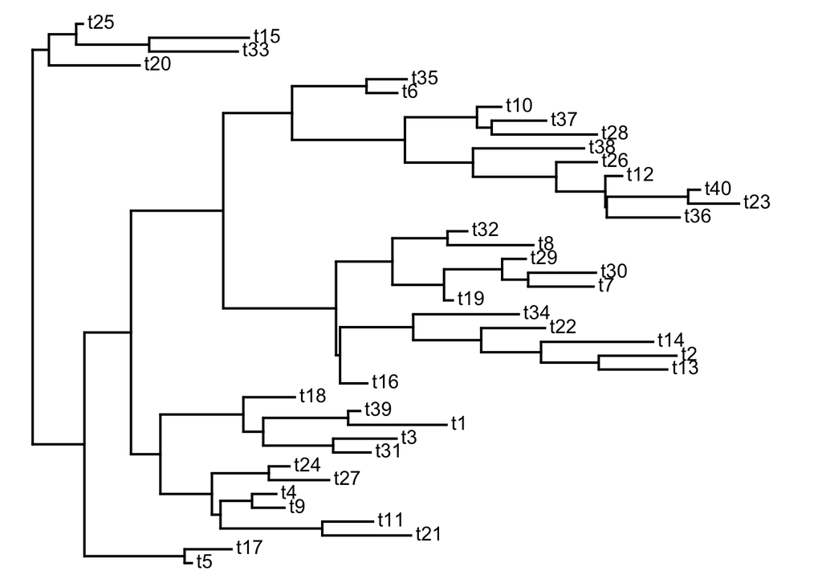

```r
## now rotate all nodes
rt.all<-rotateNodes(tree,"all")
plotTree(rt.all)
```

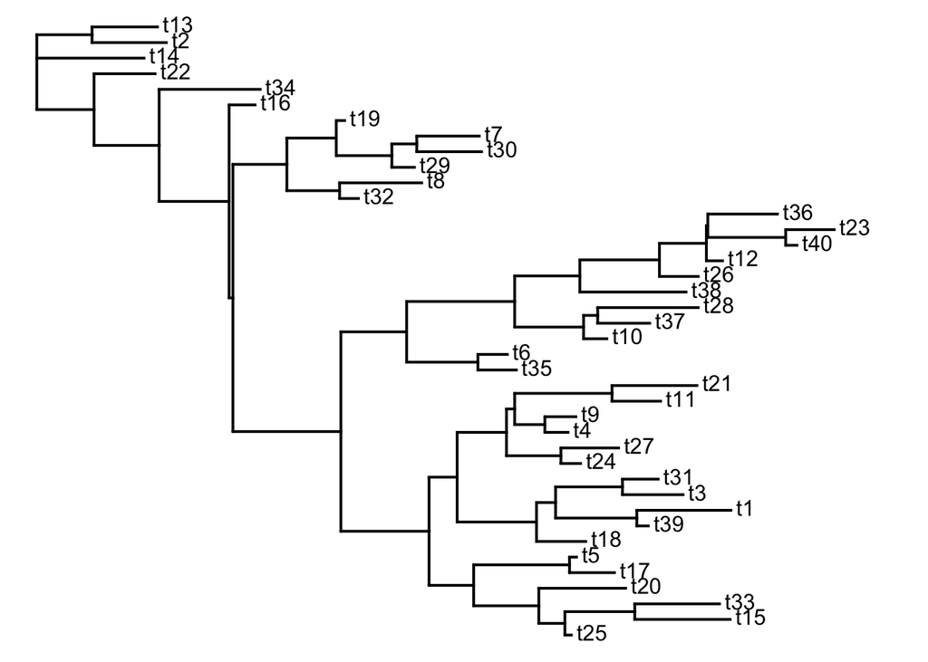

```r
## ok, now let's re-root the tree at node #67
rr.67<-root(tree,node=67)
plotTree(rr.67)
```

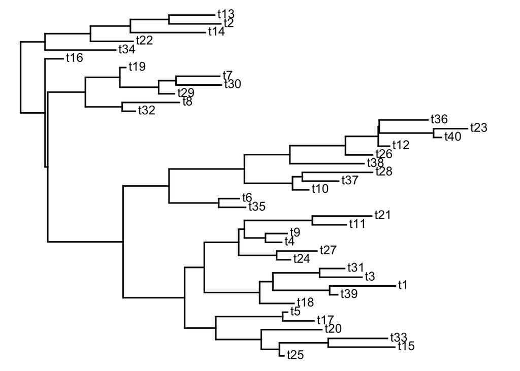

```r
## this creates a trifurcation at the root
## we could instead re-root at along an edge
rr.65<-reroot(tree,65,position=0.5*tree$edge.length[which(tree$edge[,2]==65)])
plotTree(rr.65)
```

We can also change the position of the root interactively. For instance:

> MOI: For this to work, you need to run the two following commands directly on the console

```r
# rr.interactive<-reroot(tree,interactive=TRUE)
# plotTree(rr.interactive)
```

## Comparing trees

We can, for example, check to see if our trees are equal. Trees with rotated nodes are equal. Re-rooted trees are not; however they are the same if unrooted. For example:

```r
## check if tree & rt.all are equal
all.equal(tree,rt.all)
```

```
## [1] TRUE
```

```r
## check if tree & rr.67 are equal
all.equal(tree,rr.67)
```

```
## [1] FALSE
```

```r
## check if unrooted tree & rr.67 are equal
all.equal(unroot(tree),unroot(rr.67)) ## this is a bug
```

```
## [1] TRUE
```

## Multiple trees

Finally, it is sometimes useful to store multiple phylogenies in a single object. This would be the case, for example, if we had a set of trees in a posterior sample from Bayesian phylogeny inference; or if we wanted to replicate a simulation analysis across a large number of phylogenies.

Multiple trees are stored as an object of class `"multiPhylo"`. This is just a list of objects of class `"phylo"`, with the class attribute `"multiPhylo"`. Many, but not all, functions in “ape”, “phytools”, and other R packages can be applied to both `"phylo"` and `"multiPhylo"` objects. For instance:

```r
anolis.trees<-c(anolis.tree,anolis.noPR,pr.clade,pr.tree)
print(anolis.trees,details=TRUE)
```

```
## 4 phylogenetic trees
## tree 1 : 82 tips
## tree 2 : 72 tips
## tree 3 : 8 tips
## tree 4 : 10 tips
```

```r
## round the edge lengths of the tree to 1 digits
anolis.trees<-roundBranches(anolis.trees,digits=1)
## write to file
write.tree(anolis.trees,file="example.trees")
## this is what it looks like:
cat(readLines("example.trees"),sep="\n")
```

```
## ((((((((Anolis_ahli:0.8,Anolis_allogus:0.8):0.7,Anolis_rubribarbus:1.4):2.1,Anolis_imias:3.5):0.8,((((Anolis_sagrei:1.5,(Anolis_bremeri:0.7,Anolis_quadriocellifer:0.7):0.9):0.4,Anolis_ophiolepis:1.9):0.5,Anolis_mestrei:2.4):0.8,(((Anolis_jubar:0.7,Anolis_homolechis:0.7):0.5,Anolis_confusus:1.3):0…
## ((((((((Anolis_ahli:0.8,Anolis_allogus:0.8):0.7,Anolis_rubribarbus:1.4):2.1,Anolis_imias:3.5):0.8,((((Anolis_sagrei:1.5,(Anolis_bremeri:0.7,Anolis_quadriocellifer:0.7):0.9):0.4,Anolis_ophiolepis:1.9):0.5,Anolis_mestrei:2.4):0.8,(((Anolis_jubar:0.7,Anolis_homolechis:0.7):0.5,Anolis_confusus:1.3):0…
## ((Anolis_evermanni:1.3,Anolis_stratulus:1.3):2.1,(((Anolis_krugi:2,Anolis_pulchellus:2):0.8,(Anolis_gundlachi:2.3,Anolis_poncensis:2.3):0.4):0.2,(Anolis_cooki:2.4,Anolis_cristatellus:2.4):0.6):0.5);
## ((((Anolis_evermanni:1.3,Anolis_stratulus:1.3):2.1,(((Anolis_krugi:2,Anolis_pulchellus:2):0.8,(Anolis_gundlachi:2.3,Anolis_poncensis:2.3):0.4):0.2,(Anolis_cooki:2.4,Anolis_cristatellus:2.4):0.6):0.5):2.3,Anolis_cuvieri:5.7):0.3,Anolis_occultus:6);
```

Many other tasks are also possible in R phylogenetics. For an overview, read the CRAN Phylogenetics Task View. Also check out my blog: http://blog.phytools.org, or review the PDF manuals of different R packages such as ape, phytools, and phangorn.

Written by Liam J. Revell. Last updated 31 July 2017.